# Econ 204: HW 2

Sydney Mayes, Olivia Somhegyi, Rachel Spellenberg

2023-04-29

```r
knitr::opts_chunk$set(echo = TRUE, warning = FALSE, message = FALSE, results = FALSE)
library(tidyverse)
library(here)
library(janitor)
library(equatiomatic)
```

```r
# In this homework you will be simulating alternative approaches for reducing carbon emissions among four UC campuses (UCSB, UCLA, UCI, and UCD). The dataset for this assignment is available in the file “CarbonUC.csv”, available on Canvas. The dataset contains estimates of the marginal cost of reducing carbon emission for each campus for different levels of abatement (in tons of carbon). A few notes:
# ● Current (i.e. baseline) emission for each campus are: UCSB = 90,000 tons, UCLA = 250,000 tons, UCI = 100,000 tons, UCD = 160,000 tons.
# ● Prices are in $/ton and quantities are in tons of CO2.
# ● Before opening R, I recommend drawing graphs by hand to make sure you know what you want to do

# Clean and format dataset
carbon_uc <- read_csv(here('data', 'CarbonUC.csv')) %>%
  clean_names()

long_uc <- pivot_longer(carbon_uc, cols = ucsb:ucd, names_to = 'uc', values_to = 'marginal_cost')
```

**Baseline Emissions:**

UCSB = 90,000 tons

UCLA = 250,000 tons

UCI = 100,000 tons

UCD = 160,000 tons

## Question 1

**Plot the marginal abatement cost data and estimate a linear regression model with zero intercept:**

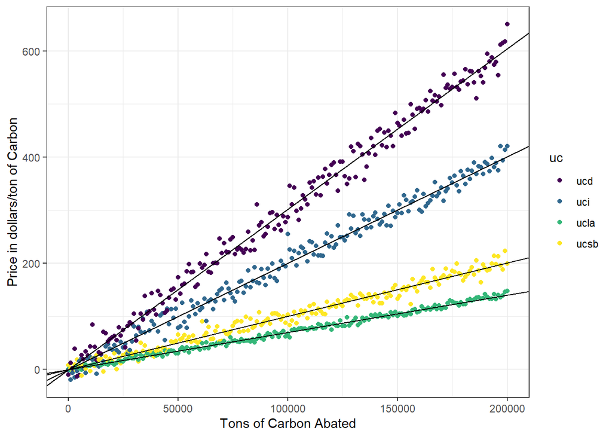

```r
# For each campus, plot the marginal abatement cost data and estimate a linear regression model with zero intercept.1 These estimated linear regressions will be your estimates of the marginal abatement cost curve for each campus, which you will use for the remainder of this analysis. Write the equation for the marginal abatement cost curve for each campus.


# Estimating linear regression models with zero intercept for each UC
# UCSB
ucsb_model <- lm(marginal_cost ~ 0 + abatement, data = filter(long_uc, uc == 'ucsb'))
#p = ucsb_model$coefficients*q
#extract_eq(ucsb_model, use_coefs = TRUE, coef_digits = 5)
# p = .001*q
ucsb_slope <- ucsb_model$coefficients

# UCLA
ucla_model <- lm(marginal_cost ~ 0 + abatement, data = filter(long_uc, uc == 'ucla'))
# ucla_model$coefficients
# p = .0007*q
ucla_slope <- ucla_model$coefficients

# UCI
uci_model <- lm(marginal_cost ~ 0 + abatement, data = filter(long_uc, uc == 'uci'))
# uci_model$coefficients
# p = .002 *q
uci_slope <- uci_model$coefficients

# UCD
ucd_model <- lm(marginal_cost ~ 0 + abatement, data = filter(long_uc, uc == 'ucd'))
# ucd_model$coefficients
# p = .003 *q
ucd_slope <- ucd_model$coefficients


# Plotting the marginal abatement costs data for each school
ggplot(data = long_uc, aes(x = abatement, y = marginal_cost, col = uc)) +
  geom_point() +
  geom_abline(slope = ucsb_slope) +
  geom_abline(slope = ucla_slope) +
  geom_abline(slope = uci_slope) +
  geom_abline(slope = ucd_slope) +
  #facet_wrap(~uc, ncol = 2) +
  scale_color_viridis_d() +
  labs(x = 'Tons of Carbon Abated', y = 'Price in dollars/ton of Carbon' ) +
  theme_bw()
```

**The marginal abatement cost curve equation for each campus:**

##### UCSB: $$\begin{aligned} \operatorname{\widehat{marginal\_cost}} &= 0.001(\operatorname{abatement}) \end{aligned}$$

##### UCLA: $$\begin{aligned} \operatorname{\widehat{marginal\_cost}} &= 7e-04(\operatorname{abatement}) \end{aligned}$$

##### UCI: $$\begin{aligned} \operatorname{\widehat{marginal\_cost}} &= 0.00201(\operatorname{abatement}) \end{aligned}$$

##### UCD: $$\begin{aligned} \operatorname{\widehat{marginal\_cost}} &= 0.00302(\operatorname{abatement}) \end{aligned}$$

## Question 2

Based on the graph, UCD is willing to pay the most for the first ton of Carbon emitted.

**Each campus’ demand curve for emissions:**

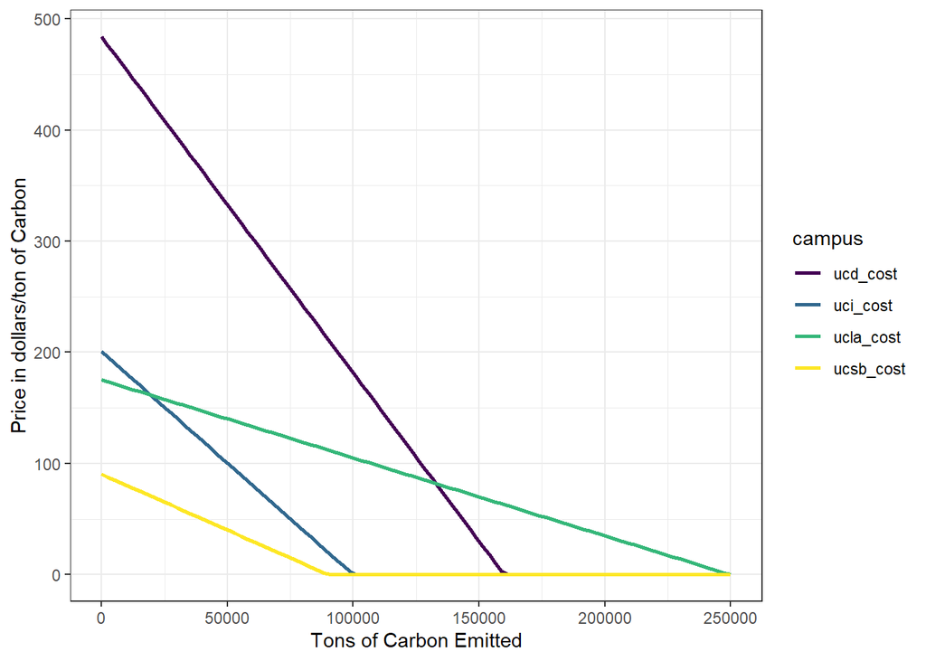

```r
# UCSB = 90,000 tons, UCLA = 250,000 tons, UCI = 100,000 tons, UCD = 160,000 tons.
# A = Qbar - Q

ucsb_base = 90000
ucla_base = 250000
uci_base = 100000
ucd_base = 160000

# e = amount of tons emitted

# UCSB
ucsb_price <- function(e) {
   p = ucsb_slope*(ucsb_base - e)
   return(p)
}

# UCLA
ucla_price <- function(e) {
   p = ucla_slope*(ucla_base - e)
   return(p)
}

# UCI
uci_price <- function(e) {
   p = uci_slope*(uci_base - e)
   return(p)
}

# UCD
ucd_price <- function(e) {
   p = ucd_slope*(ucd_base - e)
   return(p)
 }

demand_df <- data.frame(e = seq(0, 250000, length.out = 100)) %>%
  mutate(ucsb_cost = pmax(0, ucsb_price(e))) %>%
  mutate(ucla_cost = pmax(0, ucla_price(e))) %>%
  mutate(uci_cost = pmax(0, uci_price(e))) %>%
  mutate(ucd_cost = pmax(0, ucd_price(e)))

# e = x-axis; y = ucsb_cost

demand_df_long <- pivot_longer(demand_df, cols = ucsb_cost:ucd_cost, names_to = 'campus', values_to = 'marginal_wtp')

gg_demand <- ggplot(data = demand_df_long) +
  geom_line(aes(x = e, y = marginal_wtp, col = campus), size = 1) +
  scale_color_viridis_d() +
  labs(x = 'Tons of Carbon Emitted', y = 'Price in dollars/ton of Carbon' ) +
  theme_bw()

gg_demand
```

## Question 3

**Analysis of four alternative interventions for reducing carbon emissions across these four campuses.**

#### **Intervention #1: Carbon Tax of $50/ton:**

**Each campus would choose to emit:**

UCSB = 40,209.19 tons of carbon

UCLA = 178,717.5 tons of carbon

UCI = 75,096.24 tons of carbon

UCD = 143,466.4 tons of carbon

```r
# a = qbar - q
# q = qbar - a

tax = 50

ucsb_emissions = ucsb_base - (tax/ucsb_slope)
ucla_emissions = ucla_base - (tax/ucla_slope)
uci_emissions = uci_base - (tax/uci_slope)
ucd_emissions = ucd_base - (tax/ucd_slope)

# ucsb_emissions
```

**Each campus would abate:**

UCSB = 49,790.81 tons of carbon

UCLA = 71,282.47 tons of carbon

UCI = 24,903.76 tons of carbon

UCD = 16,533.62 tons of carbon

```r
ucsb_abate = tax/ucsb_slope
ucla_abate = tax/ucla_slope
uci_abate = tax/uci_slope
ucd_abate = tax/ucd_slope
```

**Total amount of emissions across all four campuses:**

437,489.3 tons of carbon

```r
total_emissions = ucsb_emissions + ucla_emissions + uci_emissions + ucd_emissions
```

**Tax revenue generated:**

UCSB = 2,010,460 dollars

UCLA = 8,935,877 dollars

UCI = 3,754,812 dollars

UCD = 7,173,319 dollars

Total = 21,874,467 dollars

```r
ucsb_revenue = tax*ucsb_emissions
ucla_revenue = tax*ucla_emissions
uci_revenue = tax*uci_emissions
ucd_revenue = tax*ucd_emissions

total_revenue = ucsb_revenue + ucla_revenue + uci_revenue + ucd_revenue
```

#### **Intervention #2: Carbon Ban at Each Campus:**

**Total cost of this ban to each campus:**

UCSB = 4,067,016 dollars

UCLA = 21,919,836 dollars

UCI = 10,038,644 dollars

UCD = 38,709,018 dollars

```r
ucsb_ban = 0.5 * ucsb_base * (ucsb_slope*ucsb_base) # 4067016
ucla_ban = 0.5 * ucla_base * (ucla_slope*ucla_base) # 21919836
uci_ban = 0.5 * uci_base * (uci_slope*uci_base) # 10038644
ucd_ban = 0.5 * ucd_base * (ucd_slope*ucd_base) # 38709018
```

#### **Intervention #3: Cap without Trade at 100,000 tons of Carbon:**

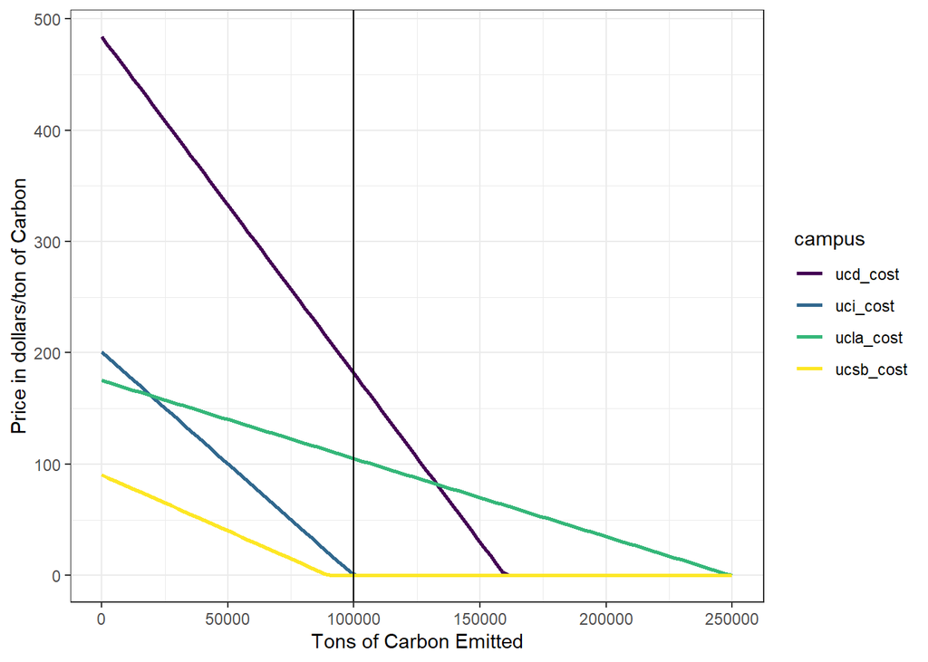

```r
gg_demand_cap <- ggplot(data = demand_df_long) +
  geom_line(aes(x = e, y = marginal_wtp, col = campus), size = 1) +
  geom_vline(xintercept = 100000) +
  scale_color_viridis_d() +
  labs(x = 'Tons of Carbon Emitted', y = 'Price in dollars/ton of Carbon' ) +
  theme_bw()

gg_demand_cap
```

**Abatement required by each campus to comply with cap:**

UCSB = 0 tons of Carbon

UCLA = 150,000 tons of Carbon

UCI = 0 tons of Carbon

UCD = 60,000 tons of Carbon

```r
cap = 100000

ucsb_cap_notrade = max(0, ucsb_base - cap) # 0
ucla_cap_notrade = max(0, ucla_base - cap) # 150000
uci_cap_notrade = max(0, uci_base - cap) # 0
ucd_cap_notrade = max(0, ucd_base - cap) # 60000
```

**Marginal cost of the last unit of abatement for each campus:**

UCSB = 0 dollars (under the cap)

UCLA = 105.22 dollars

UCD = 181.45 dollars

UCI = 0 dollars (under the cap)

```r
ucla_cap_notrade_marginal <- ucla_price(100000) # 105.2152
ucd_cap_notrade_marginal <- ucd_price(100000) # 181.4485
```

UCSB = 0 dollars (under the cap)

UCI = 0 dollars (under the cap)

```r
ucla_cap_notrade_total <- 0.5 * ucla_cap_notrade_marginal * (250000-100000) # 5260761
ucd_cap_notrade_total <- 0.5 * ucd_cap_notrade_marginal * (160000-100000) #  9072426
```

#### **Intervention #4: Cap with Trade at 100,000 tons of Carbon:**

**Each campus emissions after trade:**

UCSB will emit 28,722.95 tons of carbon

UCLA will emit 162,273.4 tons of carbon

UCI will emit 69,351.19 tons of carbon

UCD will emit 139,652.2 tons of carbon

```r
demand_df_2 <- data.frame(p = seq(0, 500, length.out = 100)) %>%
  mutate(ucsb_e = pmax(0, ucsb_base-(p/ucsb_slope))) %>%
  mutate(ucla_e = pmax(0, ucla_base-(p/ucla_slope))) %>%
  mutate(uci_e = pmax(0, uci_base-(p/uci_slope))) %>%
  mutate(ucd_e = pmax(0, ucd_base-(p/ucd_slope))) %>%
  mutate(uc_agg_e = ucsb_e + ucla_e + uci_e + ucd_e)

p_star <- spline(x = demand_df_2$uc_agg_e, y = demand_df_2$p, xout = 400000)$y

demand_df_eq <- data.frame(p = 61.5345) %>%
  mutate(ucsb_e = pmax(0, ucsb_base-(p/ucsb_slope))) %>%
  mutate(ucla_e = pmax(0, ucla_base-(p/ucla_slope))) %>%
  mutate(uci_e = pmax(0, uci_base-(p/uci_slope))) %>%
  mutate(ucd_e = pmax(0, ucd_base-(p/ucd_slope))) %>%
  mutate(uc_agg_e = ucsb_e + ucla_e + uci_e + ucd_e)
```

**Equilibrium trading price of carbon permits:**

The equilibrium trading price of carbon permits is 61.5345 dollars

**Buyer or seller of permits:**

UCSB will sell 71,277.05 permits

UCLA will buy 62,273.4 permits

UCI will sell 30,648.81 permits

UCD will buy 39,652.2 permits

```r
### UCSB
#100,000 - 28722.95

### UCLA
# 162273.4 - 100000

### UCI
# 100000 - 69351.19

### UCD
# 139652.2 - 100000
```

## Question 4

**The central campus decides to go with the “Cap with Trade” approach (Intervention #4). An altruistic** **philanthropist buys 50,000 of the permits from the cap and trade market and retires them (i.e. not** **emit the carbon), so only 350,000 tons will be emitted.**

**The new trading price among the four campuses:**

76.91305 dollars

```r
p_star_new <- spline(x = demand_df_2$uc_agg_e, y = demand_df_2$p, xout = 350000)$y
```

**Cost for the philanthropist to buy and retire these permits:**

3,076,725 dollars

```r
# Cost for philanthropist to buy/retire permits:
phil_cost = 61.5345 * 50000
# $3,076,725
```